# Fashion_MNIST_DeepLearning

```python
import numpy as np
import pandas as pd
```

Reading Data files and creating Dataframe

```python
df_train = pd.read_csv('fashion-mnist_train.csv')
df_test = pd.read_csv('fashion-mnist_test.csv')
```

Lets have a look at the data we just imported from CSV files

```python
df_train.head()
```

|  | label | pixel1 | pixel2 | pixel3 | pixel4 | pixel5 | pixel6 | pixel7 | pixel8 | pixel9 | ... | pixel775 | pixel776 | pixel777 | pixel778 | pixel779 | pixel780 | pixel781 | pixel782 | pixel783 | pixel784 |
| --- | --- | --- | --- | --- | --- | --- | --- | --- | --- | --- | --- | --- | --- | --- | --- | --- | --- | --- | --- | --- | --- |
| 0 | 2 | 0 | 0 | 0 | 0 | 0 | 0 | 0 | 0 | 0 | ... | 0 | 0 | 0 | 0 | 0 | 0 | 0 | 0 | 0 | 0 |
| 1 | 9 | 0 | 0 | 0 | 0 | 0 | 0 | 0 | 0 | 0 | ... | 0 | 0 | 0 | 0 | 0 | 0 | 0 | 0 | 0 | 0 |
| 2 | 6 | 0 | 0 | 0 | 0 | 0 | 0 | 0 | 5 | 0 | ... | 0 | 0 | 0 | 30 | 43 | 0 | 0 | 0 | 0 | 0 |
| 3 | 0 | 0 | 0 | 0 | 1 | 2 | 0 | 0 | 0 | 0 | ... | 3 | 0 | 0 | 0 | 0 | 1 | 0 | 0 | 0 | 0 |
| 4 | 3 | 0 | 0 | 0 | 0 | 0 | 0 | 0 | 0 | 0 | ... | 0 | 0 | 0 | 0 | 0 | 0 | 0 | 0 | 0 | 0 |

5 rows × 785 columns

These 784 columns are our input features which contains pixel values of 28 *28 images. Lets look at the shape of dataframes.

```python
df_train.shape
```

```
(60000, 785)
```

```python
df_test.shape
```

```
(10000, 785)
```

We have 60K samples in our training Dataset and 10K samples in test Dataset.

Let's check the labels by checking unique values in Label column

```python
df_train.label.unique()
```

```
array([2, 9, 6, 0, 3, 4, 5, 8, 7, 1])
```

So we have labels from 0 to 9 which means that we have 10 Catagories of clothing

Lets prepare our training dataset

```python
x_train = df_train.drop('label',1)
# print (x_train.head)
```

Great, we have removed 'Label' column and took rest of the columns as training samples. Label column is our target.

Let's prepare our target dataset

```python
y_train = df_train['label']
print (y_train.head(10))
```

```
0    2
1    9
2    6
3    0
4    3
5    4
6    4
7    5
8    4
9    8
Name: label, dtype: int64
```

```python
print (type(df_train))
print (type(df_train))
```

```
<class 'pandas.core.frame.DataFrame'>
<class 'pandas.core.frame.DataFrame'>
```

**Keras is a Neural Network Library build in Python. Keras works on top of 'TensorFlow' (also works with 'CNTK' and 'Theano').**

Keras accepts tensors as input, we have to convert our data into matrix format before proceeding.

```python
x_train = x_train.as_matrix()
print (type(x_train))
print (x_train.shape)
```

```
<type 'numpy.ndarray'>
(60000, 784)
```

```python
y_train = y_train.as_matrix()
print (type(y_train))
print (y_train.shape)
```

```
<type 'numpy.ndarray'>
(60000,)
```

Let us create a validation set , to check if our model is over fitting or underfitting.

```python
x_train_partial = x_train[:40000]
x_train_val = x_train[40000:]
y_train_partial = y_train[:40000]
y_train_val = y_train[40000:]
```

### Setting some hyper parameters

```python
n_classes = len(np.unique(y_train))
n_classes
```

```
10
```

```python
batch_size = int(x_train_partial.shape[0]*0.01)
batch_size
```

```
400
```

Since we are dealing with Multi - Category problem meaning we have 10 catagories against one example. This means that for every samples model will create 10 dimension Vector, which is nothing but a vector containing 10 values having probability distribution for 10 catagories. Therefore we need to convert our training labels to catagorial values.

Again Keras will help us in performing these conversion. Let's see how!

```python
from keras.utils.np_utils import to_categorical
y_train_partial = to_categorical(y_train_partial)
y_train_val = to_categorical(y_train_val)
```

Let's Create our Neural Network Model

## MLP

```python
from keras import models
from keras import layers
model = models.Sequential()
model.add(layers.Dense(32,activation='relu',input_shape=(784,)))
model.add(layers.Dense(32,activation='relu'))
model.add(layers.Dense(32,activation='relu'))
model.add(layers.Dense(32,activation='relu'))
model.add(layers.Dense(32,activation='relu'))
model.add(layers.Dense(n_classes,activation='softmax'))
```

In above model, we have one Input layer and 5 hidden layers The last layer is output layer which contains 10 neurons , as we have 10 classes in the porblem.

### Model summary

```python
model.summary()
```

```
_________________________________________________________________
Layer (type)                 Output Shape              Param #
=================================================================
dense_1 (Dense)              (None, 32)                25120
_________________________________________________________________
dense_2 (Dense)              (None, 32)                1056
_________________________________________________________________
dense_3 (Dense)              (None, 32)                1056
_________________________________________________________________
dense_4 (Dense)              (None, 32)                1056
_________________________________________________________________
dense_5 (Dense)              (None, 32)                1056
_________________________________________________________________
dense_6 (Dense)              (None, 10)                330
=================================================================
Total params: 29,674
Trainable params: 29,674
Non-trainable params: 0
_________________________________________________________________
```

Time to Compile and run the model

```python
from keras.callbacks import EarlyStopping
```

###### Earlystopping feature helsp us define the models' learning process, we can set the model to stop training if the validation accuracy or validation loss does not change by a threshold for n epochs

```python
earlystop = EarlyStopping(monitor='val_acc', min_delta=0.001, patience=5, \
                          verbose=1, mode='auto')
callbacks_list = [earlystop]
```

```python
model.compile(optimizer='adam',
              loss='categorical_crossentropy',
              metrics=['acc'])

history = model.fit(x_train_partial,
                    y_train_partial,
                    epochs=50,
                    batch_size=batch_size,
                    callbacks=callbacks_list,
                    validation_data=(x_train_val, y_train_val))
```

[output not shown]

Seems like Validation accuracy is around 85% which means that our model has learnt well. But, lets visualize if really our model has learnt and generlize for unseen data

I have tried with dropout but that led to poor model performance, meaning we are losing out on information by dropping out.

history object stores the member history as a dictionary . The details as to what happened during training.

###### Let us plot the training and validation loss

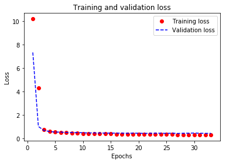

```python
import matplotlib.pyplot as plt
%matplotlib inline

history_dict = history.history
loss_values = history_dict['loss']
val_loss_values = history_dict['val_loss']

epochs = range(1,len(history.epoch)+1) # creating a range object for plotting on x axis

plt.plot(epochs, loss_values, 'ro', label='Training loss')
plt.plot(epochs, val_loss_values, 'b--', label='Validation loss')
plt.title('Training and validation loss')
plt.xlabel('Epochs')
plt.ylabel('Loss')
plt.legend()

plt.show()
```

From the graph we see that training loss consistently decreases and validation loss is in line with training loss.

```python
###### Let us plot the training and validation accuracy
```

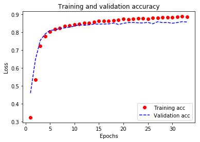

```python
acc_values = history_dict['acc']
val_acc_values = history_dict['val_acc']

plt.plot(epochs, acc_values, 'ro', label='Training acc')
plt.plot(epochs, val_acc_values, 'b--', label='Validation acc')
plt.title('Training and validation accuracy')
plt.xlabel('Epochs')
plt.ylabel('Loss')
plt.legend()

plt.show()
```

###### Lets Apply this model to our Test dataset

```python
df_test.head()
```

|  | label | pixel1 | pixel2 | pixel3 | pixel4 | pixel5 | pixel6 | pixel7 | pixel8 | pixel9 | ... | pixel775 | pixel776 | pixel777 | pixel778 | pixel779 | pixel780 | pixel781 | pixel782 | pixel783 | pixel784 |
| --- | --- | --- | --- | --- | --- | --- | --- | --- | --- | --- | --- | --- | --- | --- | --- | --- | --- | --- | --- | --- | --- |
| 0 | 0 | 0 | 0 | 0 | 0 | 0 | 0 | 0 | 9 | 8 | ... | 103 | 87 | 56 | 0 | 0 | 0 | 0 | 0 | 0 | 0 |
| 1 | 1 | 0 | 0 | 0 | 0 | 0 | 0 | 0 | 0 | 0 | ... | 34 | 0 | 0 | 0 | 0 | 0 | 0 | 0 | 0 | 0 |
| 2 | 2 | 0 | 0 | 0 | 0 | 0 | 0 | 14 | 53 | 99 | ... | 0 | 0 | 0 | 0 | 63 | 53 | 31 | 0 | 0 | 0 |
| 3 | 2 | 0 | 0 | 0 | 0 | 0 | 0 | 0 | 0 | 0 | ... | 137 | 126 | 140 | 0 | 133 | 224 | 222 | 56 | 0 | 0 |
| 4 | 3 | 0 | 0 | 0 | 0 | 0 | 0 | 0 | 0 | 0 | ... | 0 | 0 | 0 | 0 | 0 | 0 | 0 | 0 | 0 | 0 |

5 rows × 785 columns

```python
df_test.shape
```

```
(10000, 785)
```

```python
x_test = df_test.drop('label',1)
y_test = df_test['label']
x_test = x_test.as_matrix()
y_test = y_test.as_matrix()
```

```python
print (type(x_test))
print (type(y_test))
print (x_test.shape)
print (y_test.shape)
```

```
<type 'numpy.ndarray'>
<type 'numpy.ndarray'>
(10000, 784)
(10000,)
```

We have to encode the test variable values to categorical again

```python
y_test = to_categorical(y_test)
```

Time to evaluate our model on Test data!

```python
results = model.evaluate(x_test,y_test)
results
```

```
[0.4098224560499191, 0.8606]
```

Ok, we have 86.1 accuracy with test data! Which is close to the test and validation accuracies, so there is no over fitting.

We can try to improve this further by playing with the architeture. But here we will try implementing CNN

#### CNN

```python
from __future__ import print_function
import keras
from keras.models import Sequential
from keras.layers import Dense, Dropout, Flatten,initializers
from keras.layers import Conv2D, MaxPooling2D
from keras.callbacks import ModelCheckpoint
from keras import backend as K
```

```python
batch_size = 512
num_classes = 10
```

```python
# input image dimensions
im_rows, im_cols = 28, 28
```

```python
x_train_partial = x_train[:40000]
x_train_val = x_train[40000:]
y_train_partial = y_train[:40000]
y_train_val = y_train[40000:]
```

```python
# theano and tensorflow backends take the images differently , the code below is to handle that
if K.image_data_format() == 'channels_first':
    x_train_partial = x_train_partial.reshape(x_train_partial.shape[0], 1, im_rows, im_cols)
    x_train_val = x_train_val.reshape(x_train_val.shape[0], 1, im_rows, im_cols)
    x_test = x_test.reshape(x_test.shape[0], 1, im_rows, im_cols)
    input_shape = (1, im_rows, im_cols)
else:
    x_train_partial = x_train_partial.reshape(x_train_partial.shape[0],  im_rows, im_cols,1)
    x_train_val = x_train_val.reshape(x_train_val.shape[0], im_rows, im_cols,1)
    x_test = x_test.reshape(x_test.shape[0], im_rows, im_cols,1)
    input_shape = (im_rows, im_cols,1)
```

```python
x_train_partial = x_train_partial.astype('float32')
x_train_val = x_train_val.astype('float32')
x_test = x_test.astype('float32')

# x_train_partial /= 255 # normalizing
# x_train_partial /= 255 # normalizing
# x_test /= 255 # normalizing

print('x_train shape:', x_train_partial.shape)
print(x_train_partial.shape[0], 'train samples')

print('x_train_partial shape:', x_train_val.shape)
print(x_train_val.shape[0], 'train validation samples')

print('x_test shape:', x_test.shape)
print(x_test.shape[0], 'test samples')
```

```
x_train shape: (40000, 28, 28, 1)
40000 train samples
x_train_partial shape: (20000, 28, 28, 1)
20000 train validation samples
x_test shape: (10000, 28, 28, 1)
10000 test samples
```

```python
# convert class vectors to binary class matrices
y_train_partial = keras.utils.to_categorical(y_train_partial, num_classes)
y_train_val = keras.utils.to_categorical(y_train_val, num_classes)
y_test = keras.utils.to_categorical(y_test, num_classes)
```

```python
import gc
```

```python
gc.collect()
```

```
2942
```

```python
model = Sequential()
model.add(Conv2D(16, kernel_size=(3, 3),
                 activation='relu',
                 input_shape=input_shape))
# model.add(Conv2D(16, (3, 3), activation='relu'))
model.add(MaxPooling2D(pool_size=(2, 2)))

# model.add(Dropout(0.2))
model.add(Flatten())

model.add(Dense(64, activation='relu'))
# model.add(Dropout(0.1))
model.add(Dense(num_classes, activation='softmax'))
```

```python
earlystop_acc = EarlyStopping('val_acc', min_delta=0.001, patience=10, \
                          verbose=1, mode='auto')
earlystop_val = EarlyStopping('val_loss', min_delta=0.001, patience=10, \
                          verbose=1, mode='auto')
filepath="weights-improvement-{epoch:02d}-{val_acc:.2f}.hdf5"
checkpoint = ModelCheckpoint(filepath, monitor='val_acc', verbose=1, save_best_only=True, mode='max')
callbacks_list = [earlystop_acc,earlystop_val,checkpoint]
```

```python
model.summary()
```

```
_________________________________________________________________
Layer (type)                 Output Shape              Param #
=================================================================
conv2d_11 (Conv2D)           (None, 26, 26, 16)        160
_________________________________________________________________
max_pooling2d_11 (MaxPooling (None, 13, 13, 16)        0
_________________________________________________________________
flatten_11 (Flatten)         (None, 2704)              0
_________________________________________________________________
dense_27 (Dense)             (None, 64)                173120
_________________________________________________________________
dense_28 (Dense)             (None, 10)                650
=================================================================
Total params: 173,930
Trainable params: 173,930
Non-trainable params: 0
_________________________________________________________________
```

https://keras.io/callbacks/

mode: one of {auto, min, max}. If save_best_only=True, the decision to overwrite the current save file is made based on either the maximization or the minimization of the monitored quantity. For val_acc, this should be max, for val_loss this should be min, etc. In auto mode, the direction is automatically inferred from the name of the monitored quantity.

```python
epochs =50
```

```python
model.compile(optimizer='adam',
              loss='categorical_crossentropy',
              metrics=['acc'])

history = model.fit(x_train_partial,
                    y_train_partial,
                    epochs=epochs,
                    batch_size=batch_size,
                    callbacks=callbacks_list,
                    validation_data=(x_train_val, y_train_val))
```

```
Train on 40000 samples, validate on 20000 samples
Epoch 00022: early stopping
```

###### Let us plot the training and validation loss

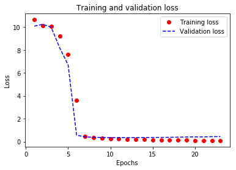

```python
import matplotlib.pyplot as plt

%matplotlib inline

history_dict = history.history
loss_values = history_dict['loss']
val_loss_values = history_dict['val_loss']

epochs = range(1,len(history.epoch)+1) # creating a range object for plotting on x axis

plt.plot(epochs, loss_values, 'ro', label='Training loss')
plt.plot(epochs, val_loss_values, 'b--', label='Validation loss')
plt.title('Training and validation loss')
plt.xlabel('Epochs')
plt.ylabel('Loss')
plt.legend()

plt.show()
```

###### Let us plot the training and validation accuracy

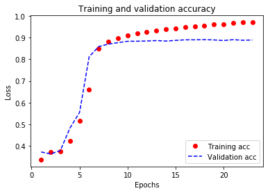

```python
acc_values = history_dict['acc']
val_acc_values = history_dict['val_acc']

plt.plot(epochs, acc_values, 'ro', label='Training acc')
plt.plot(epochs, val_acc_values, 'b--', label='Validation acc')
plt.title('Training and validation accuracy')
plt.xlabel('Epochs')
plt.ylabel('Loss')
plt.legend()

plt.show()
```

```python
y_test = df_test['label']
y_test = y_test.as_matrix()
y_test = keras.utils.to_categorical(y_test, num_classes)
```

```python
results = model.evaluate(x_test,y_test)
results
```

```
[0.41553625984191894, 0.8905]
```